# Data-Driven Employee Retention: Leveraging Survival and Uplift Modeling for Strategic HR Insights

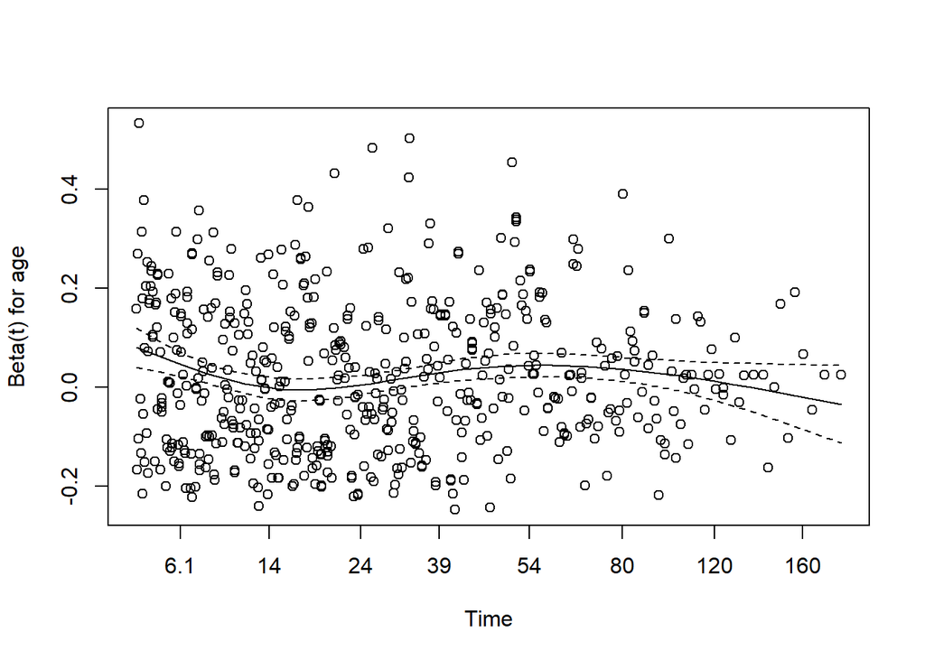

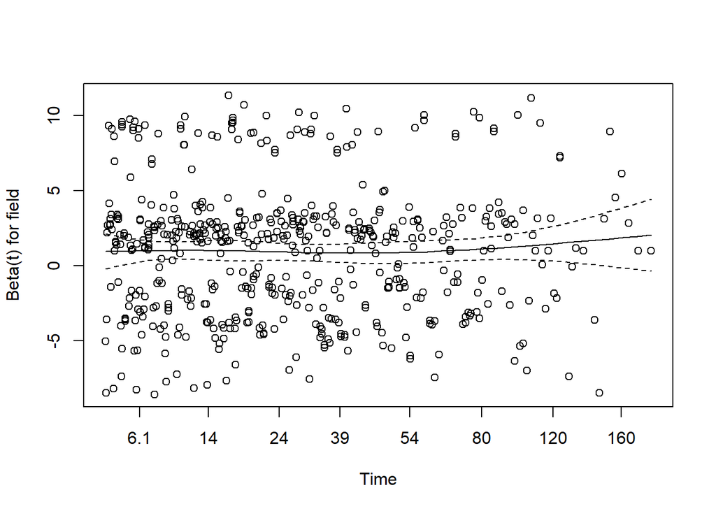

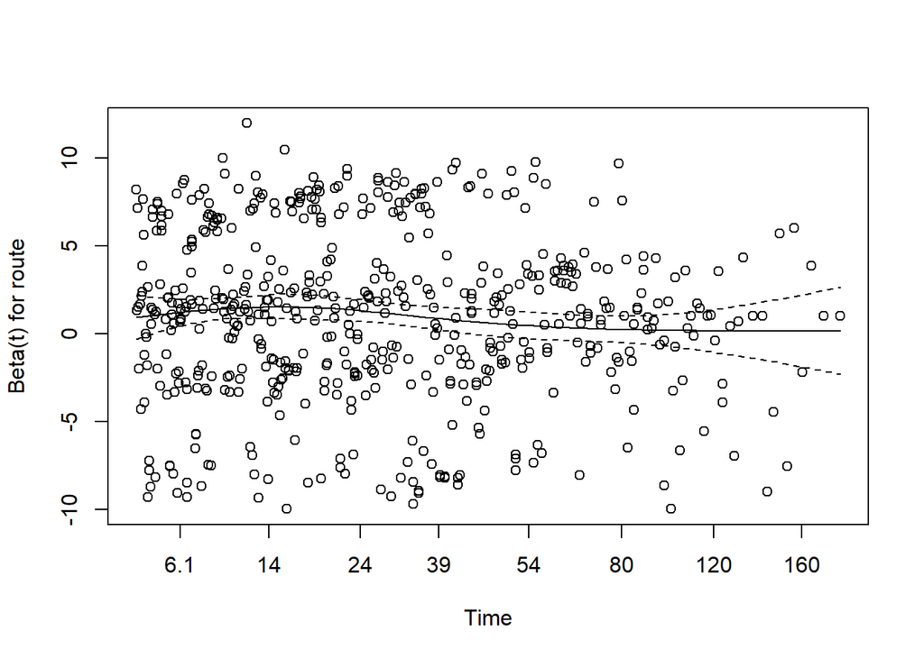

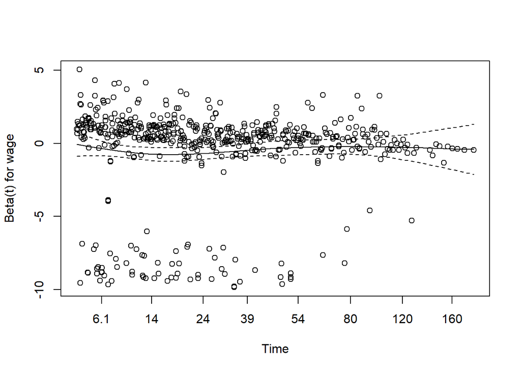

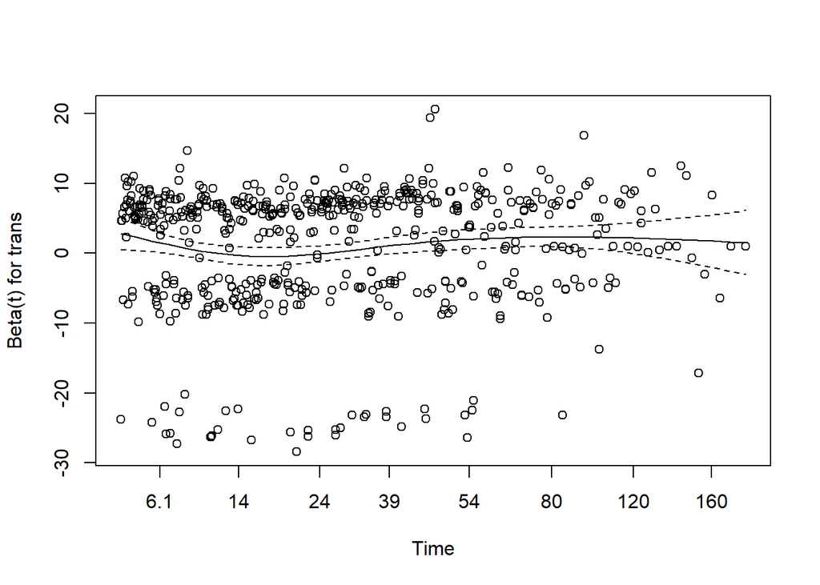

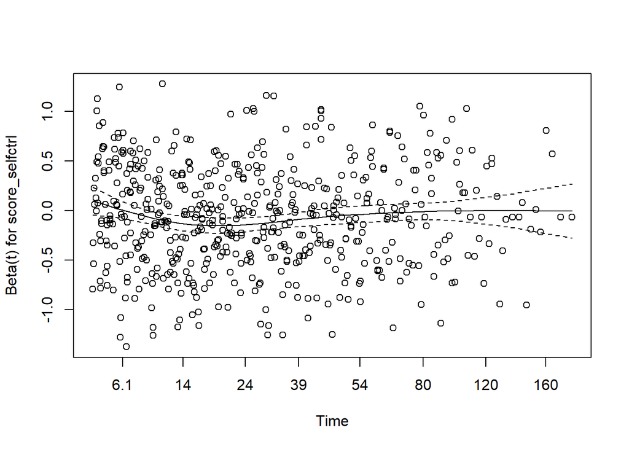

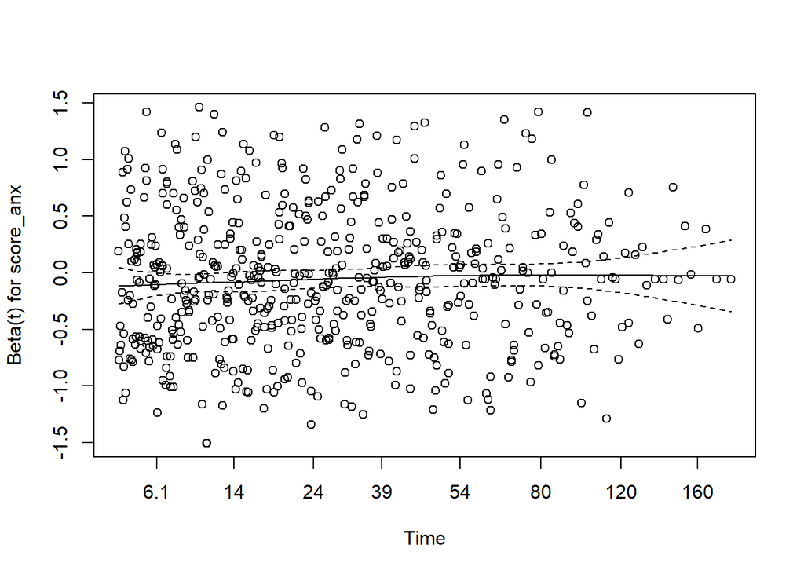

```r
# Plot the Schoenfeld residuals for each covariate
plot(ph_test)
```

We have the following insights for the aboeve Cox proportional hazard model: + Employees hired through jobsite applications have a 54.2% higher risk of quitting compared to those from other routes. This may suggest that employees who apply online might be less committed or have more options + Employees hired by submitting resumes to job sites face almost double the risk of quitting compared to other sources, likely due to higher mobility or availability of alternative job offers + Employees receiving white (tax-authorized) wages have a 37.5% lower risk of quitting compared to those paid under a grey wage system. This suggests that legal, tax-compliant wage structures contribute to better retention, likely due to higher job security and benefits. + Employees who commute on foot have a 34.4% lower risk of quitting compared to bus commuters. This could suggest that employees living closer to work may have greater job stability or satisfaction. + For each unit increase in self-control, the risk of quitting decreases by 6.3%. Employees with higher self-control are likely to stay longer, which could be due to their ability to manage work stress and maintain focus on long-term goals. + For each unit increase in anxiety, the risk of quitting decreases by 5.9%. This counterintuitive result suggests that more anxious employees might stay longer, possibly due to a fear of change or job loss.

```r
# Define function for customizing the output for Cox proportional hazard model's results
output_custom <- function(model, exp = FALSE){
  # Extract coefficients
  coeffs <- summary(model)$coefficients


  output_df <- data.frame(
    estimate = coeffs[,1],
    std_err =  coeffs[,3],
    p_val = coeffs[,5],
    significant = coeffs[,5] <= 0.05
  )

  output_df[,1:3] <- round(output_df[,1:3], 3)

  if (exp == TRUE){
    output_df$exp_est <- round(coeffs[,2], 3)
    output_df <- output_df %>% relocate(exp_est, .after = estimate)
  }

  return (output_df)
}
```

```r
output_custom(cox_model_strat, exp = TRUE)
```

```
##                     estimate exp_est std_err p_val significant
## age                    0.024   1.024   0.007 0.000        TRUE
## fieldfinance           0.351   1.421   0.140 0.012        TRUE
## fieldIT               -0.518   0.596   0.195 0.008        TRUE
## fieldmanufacture      -0.201   0.818   0.147 0.173       FALSE
## fieldretail           -0.314   0.730   0.115 0.006        TRUE
## routefriends          -0.037   0.963   0.225 0.868       FALSE
## routejobsite_apply     0.433   1.542   0.178 0.015        TRUE
## routejobsite_resume    0.683   1.980   0.180 0.000        TRUE
## routerecommend         0.250   1.283   0.168 0.138       FALSE
## wagewhite             -0.469   0.625   0.133 0.000        TRUE
## transcar              -0.172   0.842   0.100 0.086       FALSE
## transfoot             -0.421   0.656   0.176 0.017        TRUE
## score_selfctrl        -0.065   0.937   0.022 0.004        TRUE
## score_anx             -0.060   0.941   0.026 0.019        TRUE
```

```r
# Calculate the concordance index
c_index_cox <- concordance(cox_model_strat)
print(c_index_cox$concordance)
```

```
## [1] 0.6352516
```

```r
cox_model_strat_final <- coxph(Surv(exp, event) ~ age + field + strata(prof) + route +
    coach + head_gender + wage + trans + score_selfctrl + score_anx +score_anx, data = emp_df)
summary(cox_model_strat_final)
```

```
## Call:
## coxph(formula = Surv(exp, event) ~ age + field + strata(prof) +
##     route + coach + head_gender + wage + trans + score_selfctrl +
##     score_anx + score_anx, data = emp_df)
##
##   n= 1129, number of events= 571
##
##                          coef exp(coef)  se(coef)      z Pr(>|z|)
## age                  0.022247  1.022496  0.006919  3.215 0.001304 **
## fieldfinance         0.335279  1.398331  0.141756  2.365 0.018021 *
## fieldIT             -0.541747  0.581731  0.195788 -2.767 0.005657 **
## fieldmanufacture    -0.200710  0.818150  0.149028 -1.347 0.178048
## fieldretail         -0.323286  0.723767  0.115266 -2.805 0.005036 **
## routefriends        -0.034195  0.966383  0.226005 -0.151 0.879738
## routejobsite_apply   0.442925  1.557255  0.178815  2.477 0.013249 *
## routejobsite_resume  0.713682  2.041494  0.181911  3.923 8.74e-05 ***
## routerecommend       0.248957  1.282687  0.168657  1.476 0.139912
## coachmy head        -0.081567  0.921671  0.110288 -0.740 0.459554
## coachyes             0.168370  1.183375  0.139315  1.209 0.226833
## head_genderm         0.129126  1.137834  0.098767  1.307 0.191084
## wagewhite           -0.466276  0.627334  0.134182 -3.475 0.000511 ***
## transcar            -0.174091  0.840220  0.100448 -1.733 0.083070 .
## transfoot           -0.428388  0.651558  0.176444 -2.428 0.015186 *
## score_selfctrl      -0.061366  0.940479  0.022521 -2.725 0.006434 **
## score_anx           -0.057210  0.944396  0.026122 -2.190 0.028518 *
## ---
## Signif. codes:  0 '***' 0.001 '**' 0.01 '*' 0.05 '.' 0.1 ' ' 1
##
##                     exp(coef) exp(-coef) lower .95 upper .95
## age                    1.0225     0.9780    1.0087    1.0365
## fieldfinance           1.3983     0.7151    1.0591    1.8462
## fieldIT                0.5817     1.7190    0.3963    0.8538
## fieldmanufacture       0.8181     1.2223    0.6109    1.0957
## fieldretail            0.7238     1.3817    0.5774    0.9072
## routefriends           0.9664     1.0348    0.6205    1.5050
## routejobsite_apply     1.5573     0.6422    1.0969    2.2109
## routejobsite_resume    2.0415     0.4898    1.4292    2.9160
## routerecommend         1.2827     0.7796    0.9216    1.7852
## coachmy head           0.9217     1.0850    0.7425    1.1441
## coachyes               1.1834     0.8450    0.9006    1.5549
## head_genderm           1.1378     0.8789    0.9376    1.3809
## wagewhite              0.6273     1.5940    0.4823    0.8160
## transcar               0.8402     1.1902    0.6901    1.0230
## transfoot              0.6516     1.5348    0.4611    0.9208
## score_selfctrl         0.9405     1.0633    0.8999    0.9829
## score_anx              0.9444     1.0589    0.8973    0.9940
##
## Concordance= 0.641  (se = 0.015 )
## Likelihood ratio test= 100.7  on 17 df,   p=7e-14
## Wald test            = 104.3  on 17 df,   p=1e-14
## Score (logrank) test = 106.2  on 17 df,   p=6e-15
```

With a C-index of 0.635 indicates the Cox proportional hazard model is better than random but has moderate predictive ability. Therefore, we can consider the non-linear model such as Random Forest Survival models and Gradient Boosting Survival models.